# Final Project

### ASTR 519/719: Problem Set 7 MLProject Due: Apr 28 via Sakai Drop Box

#### I briefly illustrate my ideas below, which is also what I've implemented in this notebook. This is a very rough verson and I will futher imporve it after discussion.

#### 1. I focus on 20 different elements' chemical abundance of each star

#### 2. I use 19 elements' chemical abundance as the training set. Then I feed the chemical abundance to the K-Mean to get a result of the clustering. Here, the problem is: in K-Mean, you must tell the algorithm how many clusters are you looking for in advance, but I don't know, so at this step, I start from just looking for 2 clusters and use a for loop to increase the number of clusters(up to 100). Therefore, I get a result each time I increase the cluster number.

#### 3. I use the 1 element's chemical abundance left as the validation set. Then I feed the chemical abundance to the K-Mean to get another result of the clustering. Like what I described in step 2, I get a result each time I increase the cluster number.

#### 4. I define the result of step 2 as the Predicted labels, and the result of step 3 as the True labels. Then I use the accuracy_socre in K-Mean to get the accuracy score of my fit, and use the score as the uncertainty. The idea is: if two stars are in the same group, the algorithm should give me the same clustering result for both the 19-element training set and the 1-element validation set.

#### 5. I compare the accuracy score I get for different cluster numbers I am looking for and pick the highest score as the answer. For example, if I reach the highest score when I divided all stars into 8 clusters, then I think the stars should be partitioned into 8 parts.

#### 6. Then I use the cluster numbers I got in step 5 and and apply it to the scatter plot of the position of the stars by using different colors to see if the clustering result output using chemical abundance will lead to an obvious grouping in physical space.

```python
#Importing useful stuff!

## Astropy will make this a lot easier!
from astropy.io import fits
from scipy import stats
import numpy as np
import matplotlib.pyplot as plt
%matplotlib inline
from photutils import centroid_com, centroid_1dg
from photutils import DAOStarFinder
from photutils import Background2D, MedianBackground
from astropy.stats import SigmaClip
from astropy.wcs import WCS
import statistics
from astropy.visualization import make_lupton_rgb
from astropy.table import Table
from sklearn.cluster import KMeans
from sklearn.metrics import accuracy_score

## you probably won't need these, but they can help make things look nicer
from IPython.display import Latex
from matplotlib.colors import LogNorm
from matplotlib import colors
```

```python
# Read in data
data, header = fits.getdata("allStarCannon-l31c.2.fits", header=True)
fits_inf = fits.open("allStarCannon-l31c.2.fits")
```

```python
 Table(data)
```

*Table length=277371*

| APOGEE_ID str18 | FILENAME str53 | LOCATION_ID int64 | FIELD str10 | TEFF float64 | LOGG float64 | M_H float64 | ALPHA_M float64 | FE_H float64 | C_H float64 | CI_H float64 | N_H float64 | O_H float64 | NA_H float64 | MG_H float64 | AL_H float64 | SI_H float64 | P_H float64 | S_H float64 | K_H float64 | CA_H float64 | TI_H float64 | TIII_H float64 | V_H float64 | CR_H float64 | MN_H float64 | CO_H float64 | NI_H float64 | TEFF_RAWERR float64 | LOGG_RAWERR float64 | … |
| --- | --- | --- | --- | --- | --- | --- | --- | --- | --- | --- | --- | --- | --- | --- | --- | --- | --- | --- | --- | --- | --- | --- | --- | --- | --- | --- | --- | --- | --- | --- |
| VESTA |  | -9999 |  | -9999.0 | -9999.0 | -9999.0 | -9999.0 | -9999.0 | -9999.0 | -9999.0 | -9999.0 | -9999.0 | -9999.0 | -9999.0 | -9999.0 | -9999.0 | -9999.0 | -9999.0 | -9999.0 | -9999.0 | -9999.0 | -9999.0 | -9999.0 | -9999.0 | -9999.0 | -9999.0 | -9999.0 | -9999.0 | -9999.0 | … |
| 2M00000002+7417074 | cannonStar-r8-l31c.2-2M00000002+7417074-xh-censor.pkl | 5046 | 120+12 | 3727.697791686359 | 0.5310831560185305 | -0.07531490247021076 | -0.001617578566887735 | -0.09552409245989622 | -0.1312608863647262 | -0.1368746032698308 | 0.17597532109046948 | -0.010470990729600253 | 0.012414576936693546 | -0.04438545165899618 | -0.17103743430073481 | -0.06111830711776562 | -0.20929282914680541 | -0.12790628524241324 | -0.008325354955525175 | 0.10525473745926812 | 0.12509191268656566 | 0.04195613369482299 | 0.28681951295346014 | -0.09835992274451885 | -0.02490897844959526 | -0.10288094745728361 | -0.08226193427595993 | 1.2514694854069344 | 0.007490999619279537 | … |
| 2M00000019-1924498 |  | -9999 |  | -9999.0 | -9999.0 | -9999.0 | -9999.0 | -9999.0 | -9999.0 | -9999.0 | -9999.0 | -9999.0 | -9999.0 | -9999.0 | -9999.0 | -9999.0 | -9999.0 | -9999.0 | -9999.0 | -9999.0 | -9999.0 | -9999.0 | -9999.0 | -9999.0 | -9999.0 | -9999.0 | -9999.0 | -9999.0 | -9999.0 | … |
| 2M00000032+5737103 |  | -9999 |  | -9999.0 | -9999.0 | -9999.0 | -9999.0 | -9999.0 | -9999.0 | -9999.0 | -9999.0 | -9999.0 | -9999.0 | -9999.0 | -9999.0 | -9999.0 | -9999.0 | -9999.0 | -9999.0 | -9999.0 | -9999.0 | -9999.0 | -9999.0 | -9999.0 | -9999.0 | -9999.0 | -9999.0 | -9999.0 | -9999.0 | … |
| 2M00000032+5737103 |  | -9999 |  | -9999.0 | -9999.0 | -9999.0 | -9999.0 | -9999.0 | -9999.0 | -9999.0 | -9999.0 | -9999.0 | -9999.0 | -9999.0 | -9999.0 | -9999.0 | -9999.0 | -9999.0 | -9999.0 | -9999.0 | -9999.0 | -9999.0 | -9999.0 | -9999.0 | -9999.0 | -9999.0 | -9999.0 | -9999.0 | -9999.0 | … |
| 2M00000068+5710233 | cannonStar-r8-l31c.2-2M00000068+5710233-xh-censor.pkl | 4264 | N7789 | 5009.326344105176 | 3.328694107494632 | -0.11141697106358721 | -0.0017913856903005027 | -0.11658812397253798 | -0.20411792176120985 | -0.22410212832806034 | -0.03028938107780885 | -0.17200501589981296 | -0.026266636023090886 | -0.0682025996912024 | -0.006151612290927227 | -0.13519291441873282 | -0.187484801899689 | -0.09738574171131967 | -0.18645620020809037 | -0.17094928838662032 | -0.06975088733969613 | -0.48228643786963465 | -0.1550603249371217 | -0.11135917099357905 | -0.13634583443762716 | -1.2120667692437395 | -0.1468269938709932 | 6.728267470686096 | 0.011341806737259366 | … |
| 2M00000211+6327470 | cannonStar-r8-l31c.2-2M00000211+6327470-xh-censor.pkl | 4591 | 117+01 | 4657.178418192499 | 2.245738528541217 | 0.02696534742141621 | -0.01380390748596881 | 0.05389318917540738 | -0.19570300207243493 | -0.2685143386548578 | 0.4954455478659457 | 0.007149971819309454 | -0.1871606489382927 | 0.015732618334394755 | 0.005828116297355002 | 0.07910506463216031 | -0.41102361909226204 | 0.03875902685457329 | -0.04001687788535543 | 0.07419047877037102 | 0.4628572314658868 | -0.06047423557601761 | 0.23200211445366084 | 0.019162951392666494 | -0.01802065122488146 | -0.2849684006267229 | 0.03706299821095183 | 5.190348431171957 | 0.014480786790688269 | … |
| 2M00000222+5625359 | cannonStar-r8-l31c.2-2M00000222+5625359-xh-censor.pkl | 4264 | N7789 | 5003.777292951378 | 3.178615591607729 | -0.09249048054370555 | -0.009669325448045944 | -0.07786824560010197 | -0.2224436152301244 | -0.1770471469442338 | 0.08806075314291455 | -0.09091397881860955 | -0.3044792893974048 | -0.12632167329275312 | 0.07429308940076453 | -0.06779375494798638 | 0.2974984226496462 | -0.049765119530017464 | 0.05951617098912741 | -0.06458406815818611 | 0.0228821025607551 | 0.366258570260888 | -0.47436650016006293 | -0.12749043899472584 | -0.1266395529583307 | -0.09321759056814276 | -0.15592573725603875 | 9.764697073206356 | 0.016907345003211824 | … |
| 2M00000233+1452324 |  | -9999 |  | -9999.0 | -9999.0 | -9999.0 | -9999.0 | -9999.0 | -9999.0 | -9999.0 | -9999.0 | -9999.0 | -9999.0 | -9999.0 | -9999.0 | -9999.0 | -9999.0 | -9999.0 | -9999.0 | -9999.0 | -9999.0 | -9999.0 | -9999.0 | -9999.0 | -9999.0 | -9999.0 | -9999.0 | -9999.0 | -9999.0 | … |
| 2M00000317+5821383 | cannonStar-r8-l31c.2-2M00000317+5821383-xh-censor.pkl | 4424 | 116-04 | 3890.7504797952524 | 0.8572145439823199 | -0.17892051429759886 | 0.05007713728099742 | -0.17529972400182503 | -0.16370462271882094 | -0.19351550937238102 | 0.16034928325080353 | -0.03859610999867416 | -0.27267879486175706 | -0.11869585259874552 | -0.06431801770687087 | -0.1446135653880403 | -0.2856206782345193 | -0.08930255365966461 | -0.04435621940124436 | -0.128825293047398 | -0.1718109902659582 | -0.07501454230234379 | -0.1287070894361275 | -0.12967710163896312 | -0.17503074499995078 | -0.11421628595712527 | -0.16147397113576076 | 1.476711828064984 | 0.008729800590917053 | … |
| ... | ... | ... | ... | ... | ... | ... | ... | ... | ... | ... | ... | ... | ... | ... | ... | ... | ... | ... | ... | ... | ... | ... | ... | ... | ... | ... | ... | ... | ... | … |
| 2M23595591+6243276 |  | -9999 |  | -9999.0 | -9999.0 | -9999.0 | -9999.0 | -9999.0 | -9999.0 | -9999.0 | -9999.0 | -9999.0 | -9999.0 | -9999.0 | -9999.0 | -9999.0 | -9999.0 | -9999.0 | -9999.0 | -9999.0 | -9999.0 | -9999.0 | -9999.0 | -9999.0 | -9999.0 | -9999.0 | -9999.0 | -9999.0 | -9999.0 | … |
| 2M23595606+6251121 | cannonStar-r8-l31c.2-2M23595606+6251121-xh-censor.pkl | 5045 | 116+00 | 4303.9569973618645 | 1.8265232156945557 | -0.013265363103607122 | 0.004225903283142704 | -0.00018207448351821487 | -0.08172504992570005 | -0.15244494492662028 | 0.27140114303499185 | -0.0023526546426289974 | -0.2217334324965208 | 0.056121596992963735 | 0.11888445679989662 | 0.03561735180041976 | -0.18807227787721253 | 0.17834064285860712 | 0.3514273719167583 | 0.06126653148503187 | -0.10583281988297544 | 0.028881440824194627 | -0.07953731277191556 | 0.010550450971214043 | -0.032422720451029535 | 0.1588698342056009 | 0.030210546096217608 | 2.4052695445374646 | 0.010159707153244699 | … |
| 2M23595667+1452170 |  | -9999 |  | -9999.0 | -9999.0 | -9999.0 | -9999.0 | -9999.0 | -9999.0 | -9999.0 | -9999.0 | -9999.0 | -9999.0 | -9999.0 | -9999.0 | -9999.0 | -9999.0 | -9999.0 | -9999.0 | -9999.0 | -9999.0 | -9999.0 | -9999.0 | -9999.0 | -9999.0 | -9999.0 | -9999.0 | -9999.0 | -9999.0 | … |
| 2M23595669+6131251 | cannonStar-r8-l31c.2-2M23595669+6131251-xh-censor.pkl | 5045 | 116+00 | 4941.544862939506 | 2.4779319185377404 | -0.41892406528552956 | 0.0904337718640624 | -0.3995006897802512 | -0.5654414766116578 | -0.6549134026989553 | -0.14233501865710818 | -0.3391534286988111 | -0.406517686637531 | -0.3323038885434436 | -0.3580731326066811 | -0.27523785668045136 | -0.2123262342089011 | -0.3936804401846917 | -0.3608914363244046 | -0.47976838553834145 | -0.5098967555707036 | -0.24454668509137184 | -1.0400074707865141 | -0.5695405559696315 | -0.5285225864064609 | -1.159745074110433 | -0.43547161809758206 | 9.667617887835409 | 0.016761727610637534 | … |
| 2M23595676+7918072 | cannonStar-r8-l31c.2-2M23595676+7918072-xh-censor.pkl | 5047 | 120+18 | 4306.965522032579 | 1.7523301497365011 | -0.4198791945257494 | 0.20218317958652 | -0.387950793498813 | -0.3442925909465457 | -0.3437635232381159 | -0.2639731096388265 | -0.16356780218542388 | -0.4986229273554778 | -0.13096123026302045 | -0.08652553522243019 | -0.19155173056616479 | -0.15790494722280302 | -0.1622700752495094 | -0.1311805314297674 | -0.20030020213033903 | -0.5058129818912136 | 0.1874733188529557 | -0.5892999043245283 | -0.3782489723580291 | -0.565709775736684 | -0.3142053111984733 | -0.3085252003564444 | 2.5681952413274547 | 0.010592947580637203 | … |
| 2M23595756+8535275 |  | -9999 |  | -9999.0 | -9999.0 | -9999.0 | -9999.0 | -9999.0 | -9999.0 | -9999.0 | -9999.0 | -9999.0 | -9999.0 | -9999.0 | -9999.0 | -9999.0 | -9999.0 | -9999.0 | -9999.0 | -9999.0 | -9999.0 | -9999.0 | -9999.0 | -9999.0 | -9999.0 | -9999.0 | -9999.0 | -9999.0 | -9999.0 | … |
| 2M23595837+5700444 | cannonStar-r8-l31c.2-2M23595837+5700444-xh-censor.pkl | 4264 | N7789 | 4961.8055151967255 | 2.528690732238601 | -0.2834308708744036 | 0.05226770316576739 | -0.28571284667747465 | -0.46617897641376704 | -0.43887240610985656 | -0.00754397363844129 | -0.3539074197536837 | -0.513425832588086 | -0.2199444963978508 | -0.2843928342156105 | -0.2275701433520368 | 0.029694052366355136 | -0.4628761042766007 | 0.1541246030726174 | -0.21447544474192576 | -0.2900858110394127 | -0.46183068013181905 | -0.356324862176308 | -0.3191490339598431 | -0.312797124362183 | -0.23100667038096487 | -0.30030988812630477 | 11.588329108560558 | 0.02020926076382697 | … |
| 2M23595886-2009435 |  | -9999 |  | -9999.0 | -9999.0 | -9999.0 | -9999.0 | -9999.0 | -9999.0 | -9999.0 | -9999.0 | -9999.0 | -9999.0 | -9999.0 | -9999.0 | -9999.0 | -9999.0 | -9999.0 | -9999.0 | -9999.0 | -9999.0 | -9999.0 | -9999.0 | -9999.0 | -9999.0 | -9999.0 | -9999.0 | -9999.0 | -9999.0 | … |
| 2M23595886+5726058 | cannonStar-r8-l31c.2-2M23595886+5726058-xh-censor.pkl | 4424 | 116-04 | 4841.579597627247 | 2.429908957371178 | -0.16016715801006448 | 0.04830023666815724 | -0.14282290237467052 | -0.30496437815696703 | -0.3677463931864115 | 0.10880239886417999 | -0.14699726070524624 | -0.6273569313398795 | -0.10769777166764274 | -0.08690758952733874 | -0.06325726476473216 | -0.20768825899283747 | -0.04711530974715598 | -0.049082108039206644 | -0.08994006803032994 | 0.039907374977876886 | -0.03238014889120964 | -0.3949528509212764 | -0.09753904579834002 | -0.23002916976251703 | -0.1625664624269526 | -0.12175661365743663 | 7.189103230308683 | 0.013522332958968921 | … |
| 2M23595980+1528407 |  | -9999 |  | -9999.0 | -9999.0 | -9999.0 | -9999.0 | -9999.0 | -9999.0 | -9999.0 | -9999.0 | -9999.0 | -9999.0 | -9999.0 | -9999.0 | -9999.0 | -9999.0 | -9999.0 | -9999.0 | -9999.0 | -9999.0 | -9999.0 | -9999.0 | -9999.0 | -9999.0 | -9999.0 | -9999.0 | -9999.0 | -9999.0 | … |

```python
# Trim the data to get all "good" rows
good_data_index = np.where(data["LOCATION_ID"] > 0)[0] # index of the "good" rows which contains useful data
data_refined = data[good_data_index]
```

```python
# Get the chemical aboundance data
M_H = data["M_H"][good_data_index]
ALPHA_M = data["ALPHA_M"][good_data_index]
FE_H = data["FE_H"][good_data_index]
C_H = data["C_H"][good_data_index]
CI_H = data["CI_H"][good_data_index]
N_H = data["N_H"][good_data_index]
O_H = data["O_H"][good_data_index]
NA_H = data["NA_H"][good_data_index]
MG_H = data["MG_H"][good_data_index]
AL_H = data["AL_H"][good_data_index]
SI_H = data["SI_H"][good_data_index]
P_H = data["P_H"][good_data_index]
S_H = data["S_H"][good_data_index]
K_H = data["K_H"][good_data_index]
CA_H = data["CA_H"][good_data_index]
TI_H = data["TI_H"][good_data_index]
TIII_H = data["TIII_H"][good_data_index]
V_H = data["V_H"][good_data_index]
CR_H = data["CR_H"][good_data_index]
MN_H = data["MN_H"][good_data_index]
CO_H = data["CO_H"][good_data_index]
NI_H = data["NI_H"][good_data_index]

# Below are the errors. Not used in the following parts.
M_H_RAWERR = data["M_H_RAWERR"][good_data_index]
ALPHA_M_RAWERR = data["ALPHA_M_RAWERR"][good_data_index]
FE_H_RAWERR = data["FE_H_RAWERR"][good_data_index]
C_H_RAWERR = data["C_H_RAWERR"][good_data_index]
CI_H_RAWERR = data["CI_H_RAWERR"][good_data_index]
N_H_RAWERR = data["N_H_RAWERR"][good_data_index]
O_H_RAWERR = data["O_H_RAWERR"][good_data_index]
NA_H_RAWERR = data["NA_H_RAWERR"][good_data_index]
MG_H_RAWERR = data["MG_H_RAWERR"][good_data_index]
AL_H_RAWERR = data["AL_H_RAWERR"][good_data_index]
SI_H_RAWERR = data["SI_H_RAWERR"][good_data_index]
P_H_RAWERR = data["P_H_RAWERR"][good_data_index]
S_H_RAWERR = data["S_H_RAWERR"][good_data_index]
K_H_RAWERR = data["K_H_RAWERR"][good_data_index]
CA_H_RAWERR = data["CA_H_RAWERR"][good_data_index]
TI_H_RAWERR = data["TI_H_RAWERR"][good_data_index]
TIII_H_RAWERR = data["TIII_H_RAWERR"][good_data_index]
V_H_RAWERR = data["V_H_RAWERR"][good_data_index]
CR_H_RAWERR = data["CR_H_RAWERR"][good_data_index]
MN_H_RAWERR = data["MN_H_RAWERR"][good_data_index]
CO_H_RAWERR = data["CO_H_RAWERR"][good_data_index]
NI_H_RAWERR = data["NI_H_RAWERR"][good_data_index]

M_H_ERR = data["M_H_ERR"][good_data_index]
ALPHA_M_ERR = data["ALPHA_M_ERR"][good_data_index]
FE_H_ERR = data["FE_H_ERR"][good_data_index]
C_H_ERR = data["C_H_ERR"][good_data_index]
CI_H_ERR = data["CI_H_ERR"][good_data_index]
N_H_ERR = data["N_H_ERR"][good_data_index]
O_H_ERR = data["O_H_ERR"][good_data_index]
NA_H_ERR = data["NA_H_ERR"][good_data_index]
MG_H_ERR = data["MG_H_ERR"][good_data_index]
AL_H_ERR = data["AL_H_ERR"][good_data_index]
SI_H_ERR = data["SI_H_ERR"][good_data_index]
P_H_ERR = data["P_H_ERR"][good_data_index]
S_H_ERR = data["S_H_ERR"][good_data_index]
K_H_ERR = data["K_H_ERR"][good_data_index]
CA_H_ERR = data["CA_H_ERR"][good_data_index]
TI_H_ERR = data["TI_H_ERR"][good_data_index]
TIII_H_ERR = data["TIII_H_ERR"][good_data_index]
V_H_ERR = data["V_H_ERR"][good_data_index]
CR_H_ERR = data["CR_H_ERR"][good_data_index]
MN_H_ERR = data["MN_H_ERR"][good_data_index]
CO_H_ERR = data["CO_H_ERR"][good_data_index]
NI_H_ERR = data["NI_H_ERR"][good_data_index]
```

```python
# Store the abundance data into a very large array, each row represents a star and each column represents an element in the star
chemical_abundance = np.zeros((data_refined.size, 20))
chemical_abundance[:, 0] = FE_H
chemical_abundance[:, 1] = C_H
chemical_abundance[:, 2] = CI_H
chemical_abundance[:, 3] = N_H
chemical_abundance[:, 4] = O_H
chemical_abundance[:, 5] = NA_H
chemical_abundance[:, 6] = MG_H
chemical_abundance[:, 7] = AL_H
chemical_abundance[:, 8] = SI_H
chemical_abundance[:, 9] = P_H
chemical_abundance[:, 10] = S_H
chemical_abundance[:, 11] = K_H
chemical_abundance[:, 12] = CA_H
chemical_abundance[:, 13] = TI_H
chemical_abundance[:, 14] = TIII_H
chemical_abundance[:, 15] = V_H
chemical_abundance[:, 16] = CR_H
chemical_abundance[:, 17] = MN_H
chemical_abundance[:, 18] = CO_H
chemical_abundance[:, 19] = NI_H
```

```python
chemical_abundance_training_set = chemical_abundance[:, 1:] # traning set includes all chemical abundance except the abundance for Fe
chemical_abundance_validation_set = chemical_abundance[:, 0:1] # validation set is the Fe abundance
```

```python
# Get the position(RA & DEC) information of each star
ID = data["APOGEE_ID"][good_data_index]
RA = []
DEC = []
for i in ID:
    RA.append(float(i[2:4]) + float(i[4:6]) / 60 + float(i[6:8]) / 3600 + float(i[8:10]) / 360000)
    dec = float(i[11:13]) + float(i[13:15]) / 60 + float(i[15:17]) / 3600 + float(i[17:18]) / 36000
    if (i[10:11] == '+'):
        DEC.append(dec)
    else:
        DEC.append(-dec)
RA = np.array(RA)
DEC = np.array(DEC)
```

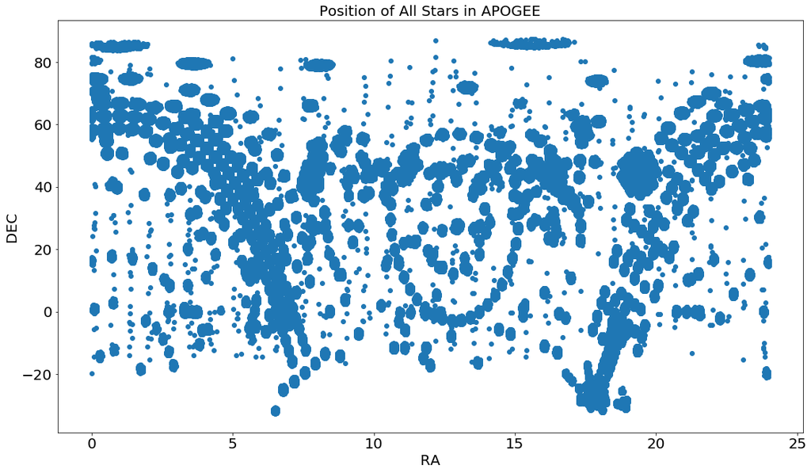

```python
# Plot the stars' positions
fig = plt.figure()
fig.set_size_inches(18.5, 10.5)
plt.scatter(RA, DEC)
plt.xlabel('RA', fontsize = 20)
plt.xticks(fontsize = 20)
plt.ylabel('DEC', fontsize = 20)
plt.yticks(fontsize = 20)
plt.title('Position of All Stars in APOGEE', fontsize = 20)
plt.show()
```

```python
# This is the step 2, 3, and 4 in my introduction, which is also very time consuming
max_possible_groups = 100
score = []
for i in range(2, max_possible_groups):
    est = KMeans(i)
    est.fit(chemical_abundance_training_set)
    y_kmeans_training = est.predict(chemical_abundance_training_set)

    est.fit(chemical_abundance_validation_set)
    y_kmeans_validation = est.predict(chemical_abundance_validation_set)
    score.append(accuracy_score(y_kmeans_validation, y_kmeans_training))
    print(str('%.3f'%(((i - 1) / (max_possible_groups - 2)) * 100) + " % complete"))

score = np.array(score)
```

```
1.020 % complete
2.041 % complete
3.061 % complete
4.082 % complete
5.102 % complete
6.122 % complete
7.143 % complete
8.163 % complete
9.184 % complete
10.204 % complete
11.224 % complete
12.245 % complete
13.265 % complete
14.286 % complete
15.306 % complete
16.327 % complete
17.347 % complete
18.367 % complete
19.388 % complete
20.408 % complete
21.429 % complete
22.449 % complete
23.469 % complete
24.490 % complete
25.510 % complete
26.531 % complete
27.551 % complete
28.571 % complete
29.592 % complete
30.612 % complete
31.633 % complete
32.653 % complete
33.673 % complete
34.694 % complete
35.714 % complete
36.735 % complete
37.755 % complete
38.776 % complete
39.796 % complete
40.816 % complete
```

[output cut: 43 more lines]

```
85.714 % complete
86.735 % complete
87.755 % complete
88.776 % complete
89.796 % complete
90.816 % complete
91.837 % complete
92.857 % complete
93.878 % complete
94.898 % complete
95.918 % complete
96.939 % complete
97.959 % complete
98.980 % complete
100.000 % complete
```

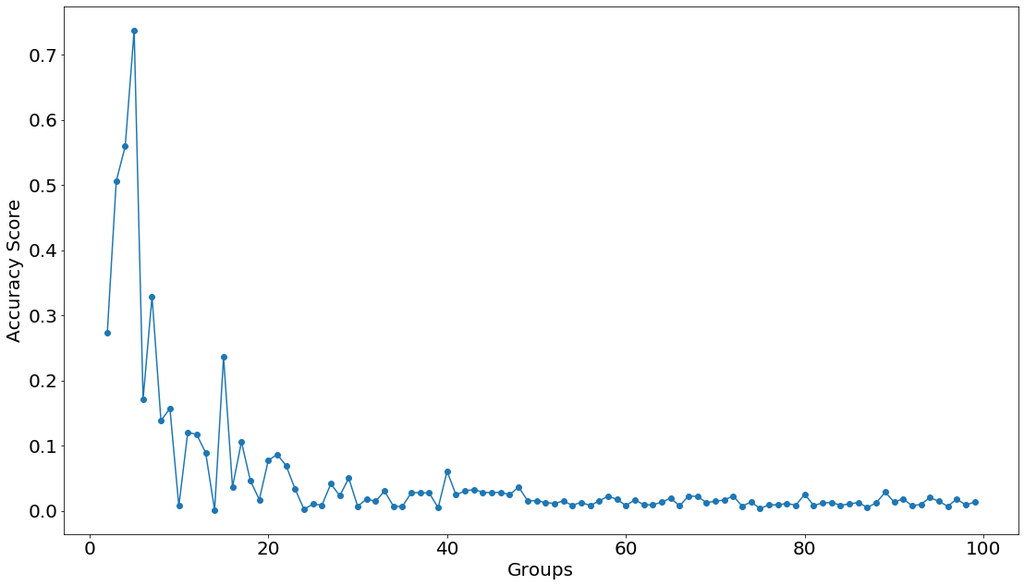

```python
# This is the step 5 in my introduction
# Plot the relation between the number of groups divided and the accuracy score
fig = plt.figure()
fig.set_size_inches(18.5, 10.5)
groups = np.arange(2, max_possible_groups, 1)
plt.plot(groups, score, 'o-')
plt.xlabel('Groups', fontsize = 20)
plt.xticks(fontsize = 20)
plt.ylabel('Accuracy Score', fontsize = 20)
plt.yticks(fontsize = 20)
plt.show()
```

#### From this figure, I can see that when I partition the stars into 5 groups, the results from the training set and the validation set is the closest, and an accuracy score of over 0.7 is not bad. Therefore, from the chemical abundance, I conclude that the stars should be put into 5 groups.

```python
# See how good the fits are
print("The highest score corresponds to a partition of " + str(2 + np.where(score == np.max(score))[0][0]) + " groups")
print("At that partition, the accuracy score is " + str(np.max(score)))
```

```
The highest score corresponds to a partition of 5 groups
At that partition, the accuracy score is 0.7369967209917476
```

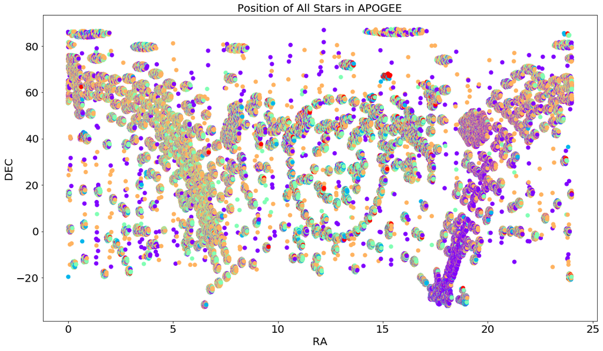

```python
# This is the step 6 in my introduction
est = KMeans(5) # partition into 5 groups is the best choice
est.fit(chemical_abundance_training_set)
y_kmeans_training = est.predict(chemical_abundance_training_set)

fig = plt.figure()
fig.set_size_inches(18.5, 10.5)
plt.scatter(RA, DEC, c=y_kmeans_training, s=50, cmap='rainbow');
plt.xlabel('RA', fontsize = 20)
plt.xticks(fontsize = 20)
plt.ylabel('DEC', fontsize = 20)
plt.yticks(fontsize = 20)
plt.title('Position of All Stars in APOGEE', fontsize = 20)
plt.show()
```

```python
# Check how many stars are in each group
group_1_index = np.where(y_kmeans_training == 0)[0]
group_2_index = np.where(y_kmeans_training == 1)[0]
group_3_index = np.where(y_kmeans_training == 2)[0]
group_4_index = np.where(y_kmeans_training == 3)[0]
group_5_index = np.where(y_kmeans_training == 4)[0]
print("There are " + str(y_kmeans_training.size) + " stars in total")
print("Group 1 has " + str(len(group_1_index)) + " members, which is " + str('%.3f'%(len(group_1_index) / y_kmeans_training.size * 100)) + " % of the total stars")
print("Group 2 has " + str(len(group_2_index)) + " members, which is " + str('%.3f'%(len(group_2_index) / y_kmeans_training.size * 100)) + " % of the total stars")
print("Group 3 has " + str(len(group_3_index)) + " members, which is " + str('%.3f'%(len(group_3_index) / y_kmeans_training.size * 100)) + " % of the total stars")
print("Group 4 has " + str(len(group_4_index)) + " members, which is " + str('%.3f'%(len(group_4_index) / y_kmeans_training.size * 100)) + " % of the total stars")
print("Group 5 has " + str(len(group_5_index)) + " members, which is " + str('%.3f'%(len(group_5_index) / y_kmeans_training.size * 100)) + " % of the total stars")
```

```
There are 164074 stars in total
Group 1 has 40339 members, which is 24.586 % of the total stars
Group 2 has 7227 members, which is 4.405 % of the total stars
Group 3 has 42473 members, which is 25.886 % of the total stars
Group 4 has 70030 members, which is 42.682 % of the total stars
Group 5 has 4005 members, which is 2.441 % of the total stars
```

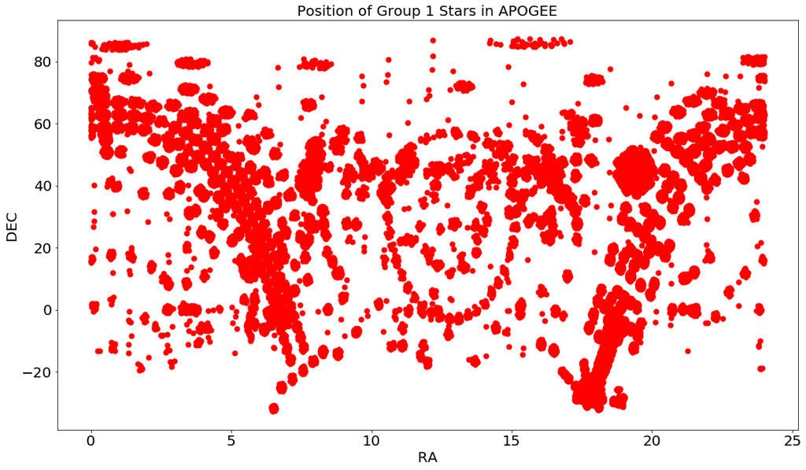

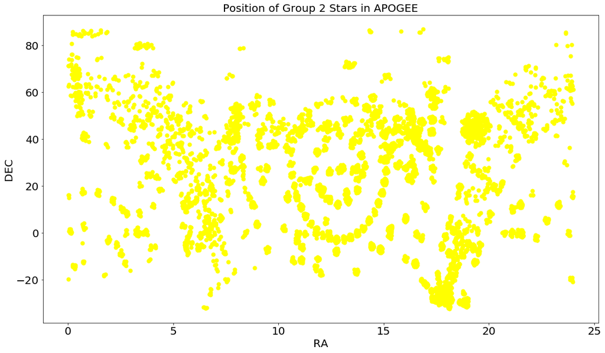

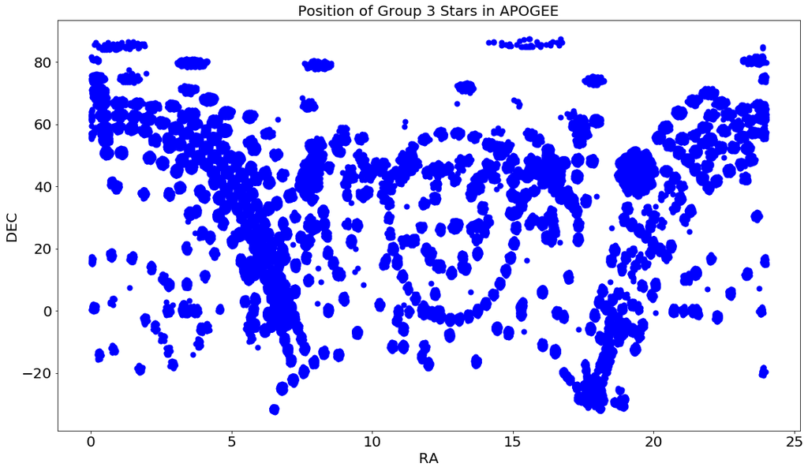

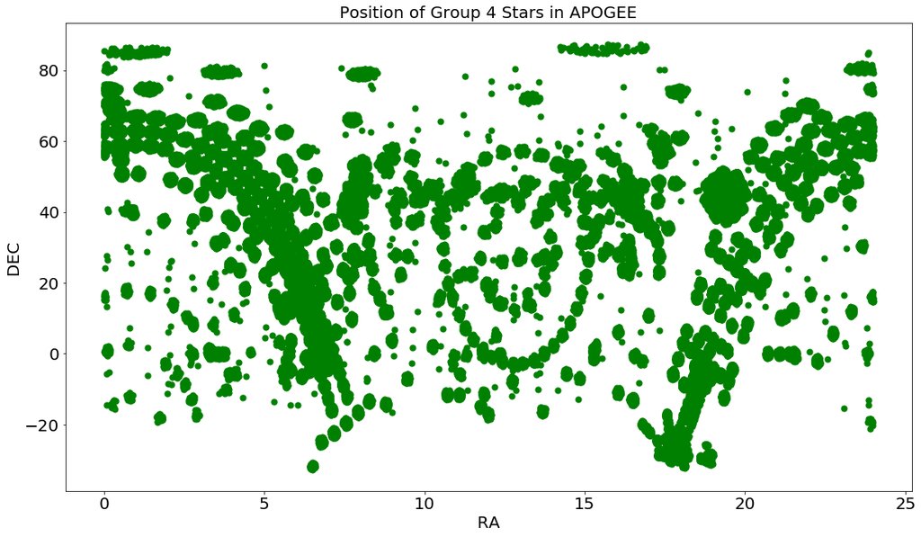

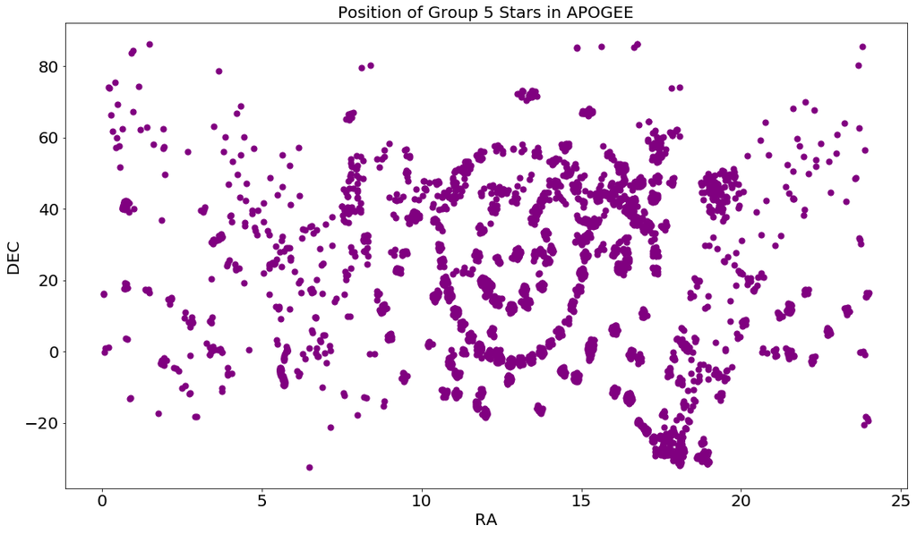

```python
# Plot the positions of stars in each group
# Group 1
fig = plt.figure()
fig.set_size_inches(18.5, 10.5)
plt.scatter(RA[group_1_index], DEC[group_1_index], c='red', s=50, cmap='rainbow');
plt.xlabel('RA', fontsize = 20)
plt.xticks(fontsize = 20)
plt.ylabel('DEC', fontsize = 20)
plt.yticks(fontsize = 20)
plt.title('Position of Group 1 Stars in APOGEE', fontsize = 20)
plt.show()

# Group 2
fig = plt.figure()
fig.set_size_inches(18.5, 10.5)
plt.scatter(RA[group_2_index], DEC[group_2_index], c='yellow', s=50, cmap='rainbow');
plt.xlabel('RA', fontsize = 20)
plt.xticks(fontsize = 20)
plt.ylabel('DEC', fontsize = 20)
plt.yticks(fontsize = 20)
plt.title('Position of Group 2 Stars in APOGEE', fontsize = 20)
plt.show()

# Group 3
fig = plt.figure()
fig.set_size_inches(18.5, 10.5)
plt.scatter(RA[group_3_index], DEC[group_3_index], c='blue', s=50, cmap='rainbow');
plt.xlabel('RA', fontsize = 20)
plt.xticks(fontsize = 20)
plt.ylabel('DEC', fontsize = 20)
plt.yticks(fontsize = 20)
plt.title('Position of Group 3 Stars in APOGEE', fontsize = 20)
plt.show()

# Group 4
fig = plt.figure()
fig.set_size_inches(18.5, 10.5)
plt.scatter(RA[group_4_index], DEC[group_4_index], c='green', s=50, cmap='rainbow');
plt.xlabel('RA', fontsize = 20)
plt.xticks(fontsize = 20)
plt.ylabel('DEC', fontsize = 20)
plt.yticks(fontsize = 20)
plt.title('Position of Group 4 Stars in APOGEE', fontsize = 20)
plt.show()

# Group 5
fig = plt.figure()
fig.set_size_inches(18.5, 10.5)
plt.scatter(RA[group_5_index], DEC[group_5_index], c='purple', s=50, cmap='rainbow');
plt.xlabel('RA', fontsize = 20)
plt.xticks(fontsize = 20)
plt.ylabel('DEC', fontsize = 20)
plt.yticks(fontsize = 20)
plt.title('Position of Group 5 Stars in APOGEE', fontsize = 20)
plt.show()
```

#### Really, there seems no obvious physical boundaries between those 5 groups. Therefore, the clustering result output using chemical abundance will NOT lead to an obvious grouping in physical space.